# Risk Factor Analysis

## Outcome Variable

**Outcome Variable:** sstunted

## Predictor Variables

**Intervention Variable:** brthmon

**Adjustment Set:**

unadjusted

## Stratifying Variables

The analysis was stratified on these variable(s):

- agecat
- studyid
- country

## Data Summary

| agecat | studyid | country | brthmon | sstunted | n_cell | n |
| --- | --- | --- | --- | --- | --- | --- |
| Birth | ki0047075b-MAL-ED | BANGLADESH | 1 | 0 | 20 | 231 |
| Birth | ki0047075b-MAL-ED | BANGLADESH | 1 | 1 | 0 | 231 |
| Birth | ki0047075b-MAL-ED | BANGLADESH | 2 | 0 | 22 | 231 |
| Birth | ki0047075b-MAL-ED | BANGLADESH | 2 | 1 | 1 | 231 |
| Birth | ki0047075b-MAL-ED | BANGLADESH | 3 | 0 | 24 | 231 |
| Birth | ki0047075b-MAL-ED | BANGLADESH | 3 | 1 | 0 | 231 |
| Birth | ki0047075b-MAL-ED | BANGLADESH | 4 | 0 | 19 | 231 |
| Birth | ki0047075b-MAL-ED | BANGLADESH | 4 | 1 | 0 | 231 |
| Birth | ki0047075b-MAL-ED | BANGLADESH | 5 | 0 | 16 | 231 |
| Birth | ki0047075b-MAL-ED | BANGLADESH | 5 | 1 | 2 | 231 |
| Birth | ki0047075b-MAL-ED | BANGLADESH | 6 | 0 | 8 | 231 |
| Birth | ki0047075b-MAL-ED | BANGLADESH | 6 | 1 | 0 | 231 |
| Birth | ki0047075b-MAL-ED | BANGLADESH | 7 | 0 | 13 | 231 |
| Birth | ki0047075b-MAL-ED | BANGLADESH | 7 | 1 | 1 | 231 |
| Birth | ki0047075b-MAL-ED | BANGLADESH | 8 | 0 | 23 | 231 |
| Birth | ki0047075b-MAL-ED | BANGLADESH | 8 | 1 | 3 | 231 |
| Birth | ki0047075b-MAL-ED | BANGLADESH | 9 | 0 | 17 | 231 |
| Birth | ki0047075b-MAL-ED | BANGLADESH | 9 | 1 | 1 | 231 |
| Birth | ki0047075b-MAL-ED | BANGLADESH | 10 | 0 | 21 | 231 |
| Birth | ki0047075b-MAL-ED | BANGLADESH | 10 | 1 | 0 | 231 |
| Birth | ki0047075b-MAL-ED | BANGLADESH | 11 | 0 | 15 | 231 |
| Birth | ki0047075b-MAL-ED | BANGLADESH | 11 | 1 | 0 | 231 |
| Birth | ki0047075b-MAL-ED | BANGLADESH | 12 | 0 | 24 | 231 |
| Birth | ki0047075b-MAL-ED | BANGLADESH | 12 | 1 | 1 | 231 |
| Birth | ki0047075b-MAL-ED | BRAZIL | 1 | 0 | 5 | 65 |
| Birth | ki0047075b-MAL-ED | BRAZIL | 1 | 1 | 0 | 65 |
| Birth | ki0047075b-MAL-ED | BRAZIL | 2 | 0 | 10 | 65 |
| Birth | ki0047075b-MAL-ED | BRAZIL | 2 | 1 | 0 | 65 |
| Birth | ki0047075b-MAL-ED | BRAZIL | 3 | 0 | 7 | 65 |
| Birth | ki0047075b-MAL-ED | BRAZIL | 3 | 1 | 0 | 65 |

[output cut: 1650 more lines]

The following strata were considered:

- agecat: 24 months, studyid: ki0047075b-MAL-ED, country: BANGLADESH
- agecat: 24 months, studyid: ki0047075b-MAL-ED, country: BRAZIL
- agecat: 24 months, studyid: ki0047075b-MAL-ED, country: INDIA
- agecat: 24 months, studyid: ki0047075b-MAL-ED, country: NEPAL
- agecat: 24 months, studyid: ki0047075b-MAL-ED, country: PERU
- agecat: 24 months, studyid: ki0047075b-MAL-ED, country: SOUTH AFRICA
- agecat: 24 months, studyid: ki0047075b-MAL-ED, country: TANZANIA, UNITED REPUBLIC OF
- agecat: 24 months, studyid: ki1000108-CMC-V-BCS-2002, country: INDIA
- agecat: 24 months, studyid: ki1000108-IRC, country: INDIA
- agecat: 24 months, studyid: ki1000109-EE, country: PAKISTAN
- agecat: 24 months, studyid: ki1017093-NIH-Birth, country: BANGLADESH
- agecat: 24 months, studyid: ki1017093b-PROVIDE, country: BANGLADESH
- agecat: 24 months, studyid: ki1066203-TanzaniaChild2, country: TANZANIA, UNITED REPUBLIC OF
- agecat: 24 months, studyid: ki1101329-Keneba, country: GAMBIA
- agecat: 24 months, studyid: ki1113344-GMS-Nepal, country: NEPAL
- agecat: 24 months, studyid: ki1114097-CMIN, country: BANGLADESH
- agecat: 24 months, studyid: ki1114097-CONTENT, country: PERU
- agecat: 24 months, studyid: ki1119695-PROBIT, country: BELARUS
- agecat: 24 months, studyid: ki1126311-ZVITAMBO, country: ZIMBABWE
- agecat: 24 months, studyid: ki1148112-LCNI-5, country: MALAWI
- agecat: 24 months, studyid: kiGH5241-JiVitA-3, country: BANGLADESH
- agecat: 24 months, studyid: kiGH5241-JiVitA-4, country: BANGLADESH
- agecat: 6 months, studyid: ki0047075b-MAL-ED, country: BANGLADESH
- agecat: 6 months, studyid: ki0047075b-MAL-ED, country: BRAZIL
- agecat: 6 months, studyid: ki0047075b-MAL-ED, country: INDIA
- agecat: 6 months, studyid: ki0047075b-MAL-ED, country: NEPAL
- agecat: 6 months, studyid: ki0047075b-MAL-ED, country: PERU
- agecat: 6 months, studyid: ki0047075b-MAL-ED, country: SOUTH AFRICA
- agecat: 6 months, studyid: ki0047075b-MAL-ED, country: TANZANIA, UNITED REPUBLIC OF
- agecat: 6 months, studyid: ki1000108-CMC-V-BCS-2002, country: INDIA
- agecat: 6 months, studyid: ki1000108-IRC, country: INDIA
- agecat: 6 months, studyid: ki1000109-EE, country: PAKISTAN
- agecat: 6 months, studyid: ki1000109-ResPak, country: PAKISTAN
- agecat: 6 months, studyid: ki1000304b-SAS-CompFeed, country: INDIA
- agecat: 6 months, studyid: ki1000304b-SAS-FoodSuppl, country: INDIA
- agecat: 6 months, studyid: ki1017093-NIH-Birth, country: BANGLADESH
- agecat: 6 months, studyid: ki1017093b-PROVIDE, country: BANGLADESH
- agecat: 6 months, studyid: ki1066203-TanzaniaChild2, country: TANZANIA, UNITED REPUBLIC OF
- agecat: 6 months, studyid: ki1101329-Keneba, country: GAMBIA
- agecat: 6 months, studyid: ki1112895-Guatemala BSC, country: GUATEMALA
- agecat: 6 months, studyid: ki1113344-GMS-Nepal, country: NEPAL
- agecat: 6 months, studyid: ki1114097-CMIN, country: BANGLADESH
- agecat: 6 months, studyid: ki1114097-CONTENT, country: PERU
- agecat: 6 months, studyid: ki1119695-PROBIT, country: BELARUS
- agecat: 6 months, studyid: ki1126311-ZVITAMBO, country: ZIMBABWE
- agecat: 6 months, studyid: ki1148112-LCNI-5, country: MALAWI
- agecat: 6 months, studyid: kiGH5241-JiVitA-3, country: BANGLADESH
- agecat: 6 months, studyid: kiGH5241-JiVitA-4, country: BANGLADESH
- agecat: Birth, studyid: ki0047075b-MAL-ED, country: BANGLADESH
- agecat: Birth, studyid: ki0047075b-MAL-ED, country: BRAZIL
- agecat: Birth, studyid: ki0047075b-MAL-ED, country: INDIA
- agecat: Birth, studyid: ki0047075b-MAL-ED, country: NEPAL
- agecat: Birth, studyid: ki0047075b-MAL-ED, country: PERU
- agecat: Birth, studyid: ki0047075b-MAL-ED, country: SOUTH AFRICA
- agecat: Birth, studyid: ki0047075b-MAL-ED, country: TANZANIA, UNITED REPUBLIC OF
- agecat: Birth, studyid: ki1000108-CMC-V-BCS-2002, country: INDIA
- agecat: Birth, studyid: ki1000108-IRC, country: INDIA
- agecat: Birth, studyid: ki1000109-EE, country: PAKISTAN
- agecat: Birth, studyid: ki1000109-ResPak, country: PAKISTAN
- agecat: Birth, studyid: ki1000304b-SAS-CompFeed, country: INDIA
- agecat: Birth, studyid: ki1017093-NIH-Birth, country: BANGLADESH
- agecat: Birth, studyid: ki1017093b-PROVIDE, country: BANGLADESH
- agecat: Birth, studyid: ki1101329-Keneba, country: GAMBIA
- agecat: Birth, studyid: ki1113344-GMS-Nepal, country: NEPAL
- agecat: Birth, studyid: ki1114097-CMIN, country: BANGLADESH
- agecat: Birth, studyid: ki1114097-CONTENT, country: PERU
- agecat: Birth, studyid: ki1119695-PROBIT, country: BELARUS
- agecat: Birth, studyid: ki1126311-ZVITAMBO, country: ZIMBABWE
- agecat: Birth, studyid: kiGH5241-JiVitA-3, country: BANGLADESH
- agecat: Birth, studyid: kiGH5241-JiVitA-4, country: BANGLADESH

### Dropped Strata

Some strata were dropped due to rare outcomes:

- agecat: Birth, studyid: ki0047075b-MAL-ED, country: BANGLADESH
- agecat: Birth, studyid: ki0047075b-MAL-ED, country: BRAZIL
- agecat: Birth, studyid: ki0047075b-MAL-ED, country: INDIA
- agecat: Birth, studyid: ki0047075b-MAL-ED, country: NEPAL
- agecat: Birth, studyid: ki0047075b-MAL-ED, country: PERU
- agecat: Birth, studyid: ki0047075b-MAL-ED, country: SOUTH AFRICA
- agecat: Birth, studyid: ki0047075b-MAL-ED, country: TANZANIA, UNITED REPUBLIC OF
- agecat: Birth, studyid: ki1000108-CMC-V-BCS-2002, country: INDIA
- agecat: Birth, studyid: ki1000108-IRC, country: INDIA
- agecat: Birth, studyid: ki1000109-EE, country: PAKISTAN
- agecat: Birth, studyid: ki1000109-ResPak, country: PAKISTAN
- agecat: Birth, studyid: ki1000304b-SAS-CompFeed, country: INDIA
- agecat: Birth, studyid: ki1017093-NIH-Birth, country: BANGLADESH
- agecat: Birth, studyid: ki1017093b-PROVIDE, country: BANGLADESH
- agecat: Birth, studyid: ki1101329-Keneba, country: GAMBIA
- agecat: Birth, studyid: ki1113344-GMS-Nepal, country: NEPAL
- agecat: Birth, studyid: ki1114097-CMIN, country: BANGLADESH
- agecat: Birth, studyid: ki1114097-CONTENT, country: PERU
- agecat: Birth, studyid: ki1119695-PROBIT, country: BELARUS
- agecat: Birth, studyid: kiGH5241-JiVitA-4, country: BANGLADESH
- agecat: 6 months, studyid: ki0047075b-MAL-ED, country: BANGLADESH
- agecat: 6 months, studyid: ki0047075b-MAL-ED, country: BRAZIL
- agecat: 6 months, studyid: ki0047075b-MAL-ED, country: INDIA
- agecat: 6 months, studyid: ki0047075b-MAL-ED, country: NEPAL
- agecat: 6 months, studyid: ki0047075b-MAL-ED, country: PERU
- agecat: 6 months, studyid: ki0047075b-MAL-ED, country: SOUTH AFRICA
- agecat: 6 months, studyid: ki0047075b-MAL-ED, country: TANZANIA, UNITED REPUBLIC OF
- agecat: 6 months, studyid: ki1000108-CMC-V-BCS-2002, country: INDIA
- agecat: 6 months, studyid: ki1000108-IRC, country: INDIA
- agecat: 6 months, studyid: ki1000109-EE, country: PAKISTAN
- agecat: 6 months, studyid: ki1000109-ResPak, country: PAKISTAN
- agecat: 6 months, studyid: ki1000304b-SAS-CompFeed, country: INDIA
- agecat: 6 months, studyid: ki1000304b-SAS-FoodSuppl, country: INDIA
- agecat: 6 months, studyid: ki1017093-NIH-Birth, country: BANGLADESH
- agecat: 6 months, studyid: ki1017093b-PROVIDE, country: BANGLADESH
- agecat: 6 months, studyid: ki1066203-TanzaniaChild2, country: TANZANIA, UNITED REPUBLIC OF
- agecat: 6 months, studyid: ki1101329-Keneba, country: GAMBIA
- agecat: 6 months, studyid: ki1112895-Guatemala BSC, country: GUATEMALA
- agecat: 6 months, studyid: ki1113344-GMS-Nepal, country: NEPAL
- agecat: 6 months, studyid: ki1114097-CMIN, country: BANGLADESH
- agecat: 6 months, studyid: ki1114097-CONTENT, country: PERU
- agecat: 6 months, studyid: ki1148112-LCNI-5, country: MALAWI
- agecat: 6 months, studyid: kiGH5241-JiVitA-4, country: BANGLADESH
- agecat: 24 months, studyid: ki0047075b-MAL-ED, country: BANGLADESH
- agecat: 24 months, studyid: ki0047075b-MAL-ED, country: BRAZIL
- agecat: 24 months, studyid: ki0047075b-MAL-ED, country: INDIA
- agecat: 24 months, studyid: ki0047075b-MAL-ED, country: NEPAL
- agecat: 24 months, studyid: ki0047075b-MAL-ED, country: PERU
- agecat: 24 months, studyid: ki0047075b-MAL-ED, country: SOUTH AFRICA
- agecat: 24 months, studyid: ki0047075b-MAL-ED, country: TANZANIA, UNITED REPUBLIC OF
- agecat: 24 months, studyid: ki1000108-CMC-V-BCS-2002, country: INDIA
- agecat: 24 months, studyid: ki1000108-IRC, country: INDIA
- agecat: 24 months, studyid: ki1000109-EE, country: PAKISTAN
- agecat: 24 months, studyid: ki1017093-NIH-Birth, country: BANGLADESH
- agecat: 24 months, studyid: ki1017093b-PROVIDE, country: BANGLADESH
- agecat: 24 months, studyid: ki1066203-TanzaniaChild2, country: TANZANIA, UNITED REPUBLIC OF
- agecat: 24 months, studyid: ki1113344-GMS-Nepal, country: NEPAL
- agecat: 24 months, studyid: ki1114097-CMIN, country: BANGLADESH
- agecat: 24 months, studyid: ki1114097-CONTENT, country: PERU
- agecat: 24 months, studyid: ki1119695-PROBIT, country: BELARUS
- agecat: 24 months, studyid: ki1126311-ZVITAMBO, country: ZIMBABWE
- agecat: 24 months, studyid: ki1148112-LCNI-5, country: MALAWI
- agecat: 24 months, studyid: kiGH5241-JiVitA-4, country: BANGLADESH

## Methods Detail

We’re interested in the causal parameters $E[Y_a]$ for all values of $a \in \mathcal{A}$. These parameters represent the mean outcome if, possibly contrary to fact, we intervened to set all units to have $A=a$. Under the randomization and positivity assumptions, these are identified by the statistical parameters $\psi_a=E_W[E_{Y|A,W}(Y|A=a,W)]$. In addition, we’re interested in the mean of $Y$, $E[Y]$ under no intervention (the observed mean). We will estimate these parameters by using SuperLearner to fit the relevant likelihood factors – $E_{Y|A,W}(Y|A=a,W)$ and $p(A=a|W)$, and then updating our likelihood fit using a joint TMLE.

For unadjusted analyses ($W=\{\}$), initial likelihoods were estimated using Lrnr_glm to estimate the simple $E(Y|A)$ and Lrnr_mean to estimate $p(A)$. For adjusted analyses, a small library containing Lrnr_glmnet, Lrnr_xgboost, and Lrnr_mean was used.

Having estimated these parameters, we will then use the delta method to estimate relative risks and attributable risks relative to a prespecified baseline level of $A$.

# Results Detail

## Results Plots

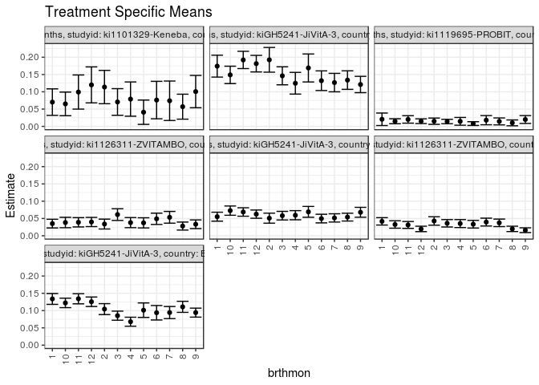

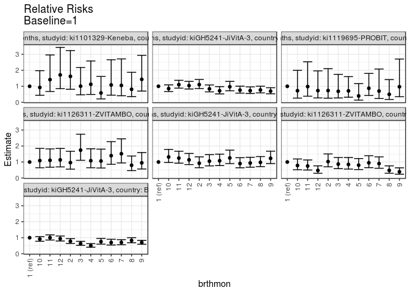

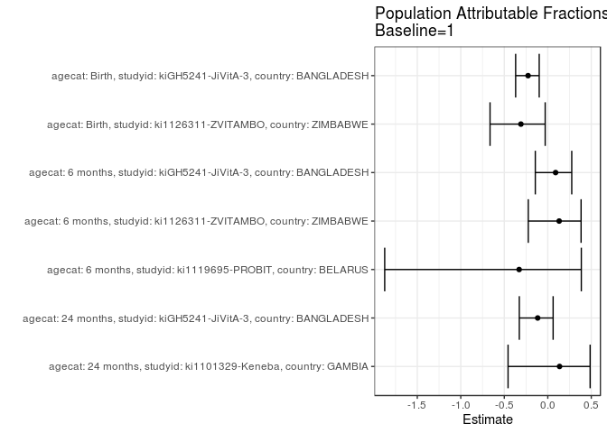

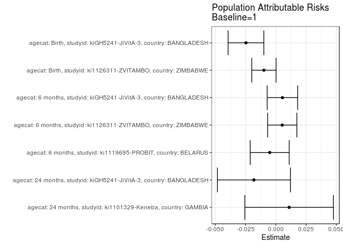

## Results Table

### Parameter: TSM

| agecat | studyid | country | intervention_level | baseline_level | estimate | ci_lower | ci_upper |
| --- | --- | --- | --- | --- | --- | --- | --- |
| Birth | ki1126311-ZVITAMBO | ZIMBABWE | 1 | NA | 0.0416977 | 0.0310063 | 0.0523891 |
| Birth | ki1126311-ZVITAMBO | ZIMBABWE | 2 | NA | 0.0427757 | 0.0305475 | 0.0550038 |
| Birth | ki1126311-ZVITAMBO | ZIMBABWE | 3 | NA | 0.0361135 | 0.0253904 | 0.0468366 |
| Birth | ki1126311-ZVITAMBO | ZIMBABWE | 4 | NA | 0.0352823 | 0.0238011 | 0.0467634 |
| Birth | ki1126311-ZVITAMBO | ZIMBABWE | 5 | NA | 0.0334317 | 0.0223833 | 0.0444800 |
| Birth | ki1126311-ZVITAMBO | ZIMBABWE | 6 | NA | 0.0395778 | 0.0282449 | 0.0509107 |
| Birth | ki1126311-ZVITAMBO | ZIMBABWE | 7 | NA | 0.0374150 | 0.0265681 | 0.0482618 |
| Birth | ki1126311-ZVITAMBO | ZIMBABWE | 8 | NA | 0.0198886 | 0.0121701 | 0.0276072 |
| Birth | ki1126311-ZVITAMBO | ZIMBABWE | 9 | NA | 0.0161663 | 0.0093078 | 0.0230247 |
| Birth | ki1126311-ZVITAMBO | ZIMBABWE | 10 | NA | 0.0326609 | 0.0218629 | 0.0434589 |
| Birth | ki1126311-ZVITAMBO | ZIMBABWE | 11 | NA | 0.0312764 | 0.0213571 | 0.0411957 |
| Birth | ki1126311-ZVITAMBO | ZIMBABWE | 12 | NA | 0.0197531 | 0.0119285 | 0.0275777 |
| Birth | kiGH5241-JiVitA-3 | BANGLADESH | 1 | NA | 0.1337127 | 0.1180108 | 0.1494145 |
| Birth | kiGH5241-JiVitA-3 | BANGLADESH | 2 | NA | 0.1042627 | 0.0884594 | 0.1200659 |
| Birth | kiGH5241-JiVitA-3 | BANGLADESH | 3 | NA | 0.0852523 | 0.0721044 | 0.0984002 |
| Birth | kiGH5241-JiVitA-3 | BANGLADESH | 4 | NA | 0.0677966 | 0.0547976 | 0.0807956 |
| Birth | kiGH5241-JiVitA-3 | BANGLADESH | 5 | NA | 0.1012071 | 0.0802366 | 0.1221775 |
| Birth | kiGH5241-JiVitA-3 | BANGLADESH | 6 | NA | 0.0937500 | 0.0728448 | 0.1146552 |
| Birth | kiGH5241-JiVitA-3 | BANGLADESH | 7 | NA | 0.0942948 | 0.0767543 | 0.1118352 |
| Birth | kiGH5241-JiVitA-3 | BANGLADESH | 8 | NA | 0.1108584 | 0.0948528 | 0.1268640 |
| Birth | kiGH5241-JiVitA-3 | BANGLADESH | 9 | NA | 0.0941385 | 0.0811417 | 0.1071354 |
| Birth | kiGH5241-JiVitA-3 | BANGLADESH | 10 | NA | 0.1221812 | 0.1084961 | 0.1358664 |
| Birth | kiGH5241-JiVitA-3 | BANGLADESH | 11 | NA | 0.1341991 | 0.1195399 | 0.1488584 |
| Birth | kiGH5241-JiVitA-3 | BANGLADESH | 12 | NA | 0.1255673 | 0.1118248 | 0.1393098 |
| 6 months | ki1119695-PROBIT | BELARUS | 1 | NA | 0.0204918 | 0.0024183 | 0.0385653 |
| 6 months | ki1119695-PROBIT | BELARUS | 2 | NA | 0.0150054 | 0.0059302 | 0.0240805 |
| 6 months | ki1119695-PROBIT | BELARUS | 3 | NA | 0.0140713 | 0.0077469 | 0.0203957 |
| 6 months | ki1119695-PROBIT | BELARUS | 4 | NA | 0.0145852 | 0.0034123 | 0.0257581 |
| 6 months | ki1119695-PROBIT | BELARUS | 5 | NA | 0.0081008 | 0.0026684 | 0.0135332 |
| 6 months | ki1119695-PROBIT | BELARUS | 6 | NA | 0.0179372 | 0.0046510 | 0.0312235 |

[output cut: 54 more lines]

### Parameter: E(Y)

| agecat | studyid | country | intervention_level | baseline_level | estimate | ci_lower | ci_upper |
| --- | --- | --- | --- | --- | --- | --- | --- |
| Birth | ki1126311-ZVITAMBO | ZIMBABWE | NA | NA | 0.0318559 | 0.0289336 | 0.0347781 |
| Birth | kiGH5241-JiVitA-3 | BANGLADESH | NA | NA | 0.1090180 | 0.1044666 | 0.1135695 |
| 6 months | ki1119695-PROBIT | BELARUS | NA | NA | 0.0154178 | 0.0100323 | 0.0208033 |
| 6 months | ki1126311-ZVITAMBO | ZIMBABWE | NA | NA | 0.0404891 | 0.0363397 | 0.0446385 |
| 6 months | kiGH5241-JiVitA-3 | BANGLADESH | NA | NA | 0.0606746 | 0.0568229 | 0.0645262 |
| 24 months | ki1101329-Keneba | GAMBIA | NA | NA | 0.0811594 | 0.0682689 | 0.0940499 |
| 24 months | kiGH5241-JiVitA-3 | BANGLADESH | NA | NA | 0.1560473 | 0.1472898 | 0.1648047 |

### Parameter: RR

| agecat | studyid | country | intervention_level | baseline_level | estimate | ci_lower | ci_upper |
| --- | --- | --- | --- | --- | --- | --- | --- |
| Birth | ki1126311-ZVITAMBO | ZIMBABWE | 1 | 1 | 1.0000000 | 1.0000000 | 1.0000000 |
| Birth | ki1126311-ZVITAMBO | ZIMBABWE | 2 | 1 | 1.0258521 | 0.6987347 | 1.5061117 |
| Birth | ki1126311-ZVITAMBO | ZIMBABWE | 3 | 1 | 0.8660791 | 0.5850308 | 1.2821427 |
| Birth | ki1126311-ZVITAMBO | ZIMBABWE | 4 | 1 | 0.8461442 | 0.5591421 | 1.2804616 |
| Birth | ki1126311-ZVITAMBO | ZIMBABWE | 5 | 1 | 0.8017629 | 0.5277036 | 1.2181529 |
| Birth | ki1126311-ZVITAMBO | ZIMBABWE | 6 | 1 | 0.9491613 | 0.6462690 | 1.3940128 |
| Birth | ki1126311-ZVITAMBO | ZIMBABWE | 7 | 1 | 0.8972911 | 0.6093280 | 1.3213429 |
| Birth | ki1126311-ZVITAMBO | ZIMBABWE | 8 | 1 | 0.4769718 | 0.2995609 | 0.7594521 |
| Birth | ki1126311-ZVITAMBO | ZIMBABWE | 9 | 1 | 0.3877021 | 0.2361652 | 0.6364737 |
| Birth | ki1126311-ZVITAMBO | ZIMBABWE | 10 | 1 | 0.7832784 | 0.5154839 | 1.1901926 |
| Birth | ki1126311-ZVITAMBO | ZIMBABWE | 11 | 1 | 0.7500755 | 0.4988693 | 1.1277768 |
| Birth | ki1126311-ZVITAMBO | ZIMBABWE | 12 | 1 | 0.4737213 | 0.2955266 | 0.7593628 |
| Birth | kiGH5241-JiVitA-3 | BANGLADESH | 1 | 1 | 1.0000000 | 1.0000000 | 1.0000000 |
| Birth | kiGH5241-JiVitA-3 | BANGLADESH | 2 | 1 | 0.7797517 | 0.6420181 | 0.9470336 |
| Birth | kiGH5241-JiVitA-3 | BANGLADESH | 3 | 1 | 0.6375786 | 0.5257934 | 0.7731296 |
| Birth | kiGH5241-JiVitA-3 | BANGLADESH | 4 | 1 | 0.5070321 | 0.4067011 | 0.6321142 |
| Birth | kiGH5241-JiVitA-3 | BANGLADESH | 5 | 1 | 0.7568996 | 0.5988965 | 0.9565877 |
| Birth | kiGH5241-JiVitA-3 | BANGLADESH | 6 | 1 | 0.7011303 | 0.5441560 | 0.9033875 |
| Birth | kiGH5241-JiVitA-3 | BANGLADESH | 7 | 1 | 0.7052045 | 0.5664141 | 0.8780032 |
| Birth | kiGH5241-JiVitA-3 | BANGLADESH | 8 | 1 | 0.8290796 | 0.6867897 | 1.0008494 |
| Birth | kiGH5241-JiVitA-3 | BANGLADESH | 9 | 1 | 0.7040361 | 0.5923109 | 0.8368356 |
| Birth | kiGH5241-JiVitA-3 | BANGLADESH | 10 | 1 | 0.9137596 | 0.7798298 | 1.0706908 |
| Birth | kiGH5241-JiVitA-3 | BANGLADESH | 11 | 1 | 1.0036382 | 0.8552792 | 1.1777319 |
| Birth | kiGH5241-JiVitA-3 | BANGLADESH | 12 | 1 | 0.9390833 | 0.7958284 | 1.1081251 |
| 6 months | ki1119695-PROBIT | BELARUS | 1 | 1 | 1.0000000 | 1.0000000 | 1.0000000 |
| 6 months | ki1119695-PROBIT | BELARUS | 2 | 1 | 0.7322615 | 0.2549421 | 2.1032496 |
| 6 months | ki1119695-PROBIT | BELARUS | 3 | 1 | 0.6866792 | 0.2702442 | 1.7448229 |
| 6 months | ki1119695-PROBIT | BELARUS | 4 | 1 | 0.7117593 | 0.3156736 | 1.6048266 |
| 6 months | ki1119695-PROBIT | BELARUS | 5 | 1 | 0.3953195 | 0.1337366 | 1.1685474 |
| 6 months | ki1119695-PROBIT | BELARUS | 6 | 1 | 0.8753363 | 0.4248208 | 1.8036162 |

[output cut: 54 more lines]

### Parameter: PAR

| agecat | studyid | country | intervention_level | baseline_level | estimate | ci_lower | ci_upper |
| --- | --- | --- | --- | --- | --- | --- | --- |
| Birth | ki1126311-ZVITAMBO | ZIMBABWE | 1 | NA | -0.0098418 | -0.0198776 | 0.0001939 |
| Birth | kiGH5241-JiVitA-3 | BANGLADESH | 1 | NA | -0.0246946 | -0.0394548 | -0.0099345 |
| 6 months | ki1119695-PROBIT | BELARUS | 1 | NA | -0.0050740 | -0.0211775 | 0.0110295 |
| 6 months | ki1126311-ZVITAMBO | ZIMBABWE | 1 | NA | 0.0052949 | -0.0067649 | 0.0173547 |
| 6 months | kiGH5241-JiVitA-3 | BANGLADESH | 1 | NA | 0.0054507 | -0.0071620 | 0.0180633 |
| 24 months | ki1101329-Keneba | GAMBIA | 1 | NA | 0.0109840 | -0.0256502 | 0.0476182 |
| 24 months | kiGH5241-JiVitA-3 | BANGLADESH | 1 | NA | -0.0181269 | -0.0483086 | 0.0120548 |

### Parameter: PAF

| agecat | studyid | country | intervention_level | baseline_level | estimate | ci_lower | ci_upper |
| --- | --- | --- | --- | --- | --- | --- | --- |
| Birth | ki1126311-ZVITAMBO | ZIMBABWE | 1 | NA | -0.3089490 | -0.6636470 | -0.0298744 |
| Birth | kiGH5241-JiVitA-3 | BANGLADESH | 1 | NA | -0.2265187 | -0.3694083 | -0.0985388 |
| 6 months | ki1119695-PROBIT | BELARUS | 1 | NA | -0.3291000 | -1.8744679 | 0.3854491 |
| 6 months | ki1126311-ZVITAMBO | ZIMBABWE | 1 | NA | 0.1307741 | -0.2240812 | 0.3827585 |
| 6 months | kiGH5241-JiVitA-3 | BANGLADESH | 1 | NA | 0.0898347 | -0.1433846 | 0.2754835 |
| 24 months | ki1101329-Keneba | GAMBIA | 1 | NA | 0.1353383 | -0.4566204 | 0.4867298 |
| 24 months | kiGH5241-JiVitA-3 | BANGLADESH | 1 | NA | -0.1161629 | -0.3272882 | 0.0613797 |